# trabajo 3: Microsimulación + Clusters

### **4.2.4 Visualización Espacial de los Clústeres**

```r
## -----------------------------------------------------------------------------
## 7. MAPA 2: CLUSTERS PERFILADOS (CORREGIDO)
## -----------------------------------------------------------------------------
message("--- (7/8) GENERANDO MAPA DE CLUSTERS ---")
```

```
## --- (7/8) GENERANDO MAPA DE CLUSTERS ---
```

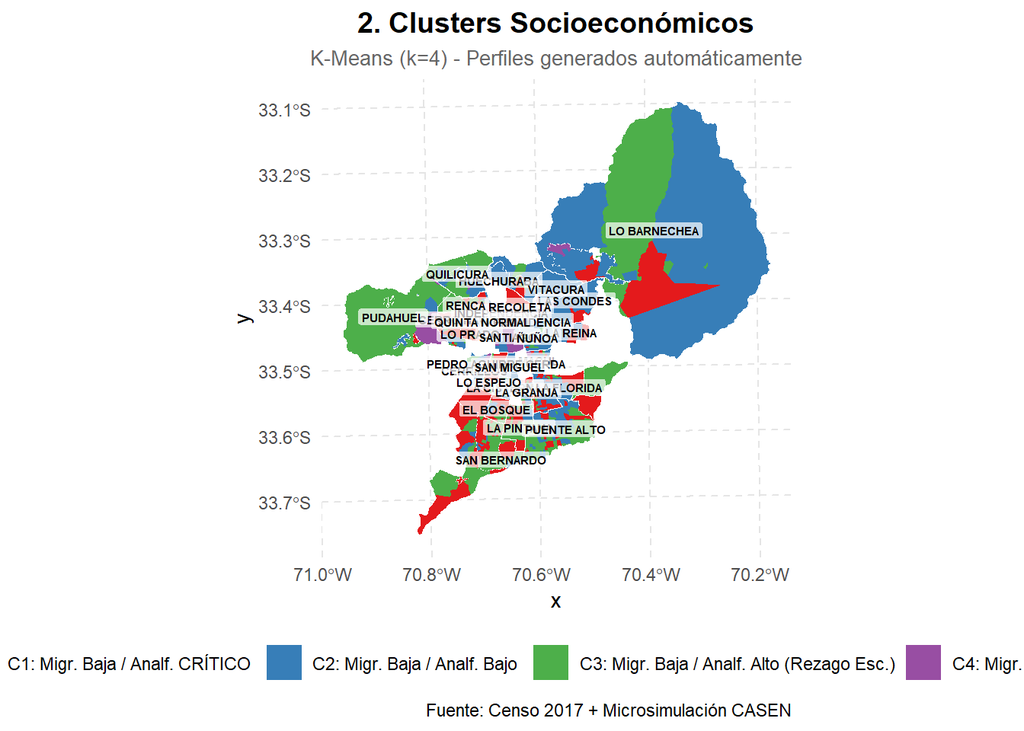

```r
# 1. Recalcular estadísticas globales (por seguridad)
g_analf = mean(sf_master$tasa_analfabetismo, na.rm = TRUE)
sd_analf = sd(sf_master$tasa_analfabetismo, na.rm = TRUE)
g_migra = mean(sf_master$ptje_migrantes, na.rm = TRUE)
sd_migra = sd(sf_master$ptje_migrantes, na.rm = TRUE)
g_educ  = mean(sf_master$ptje_nunca_asistio, na.rm = TRUE)
sd_educ = sd(sf_master$ptje_nunca_asistio, na.rm = TRUE)

# 2. Crear Perfiles (asegurando que sf_master tenga la columna 'cluster')
perfiles = sf_master %>%
  st_drop_geometry() %>%
  group_by(cluster) %>%
  summarise(
    m_analf = mean(tasa_analfabetismo, na.rm = TRUE),
    m_migra = mean(ptje_migrantes, na.rm = TRUE),
    m_educ = mean(ptje_nunca_asistio, na.rm = TRUE)
  ) %>%
  ungroup() %>%
  mutate(
    txt_migra = case_when(
      m_migra > g_migra + sd_migra ~ "Migr. MUY ALTA",
      m_migra > g_migra            ~ "Migr. Alta",
      TRUE                         ~ "Migr. Baja"
    ),
    txt_analf = case_when(
      m_analf > g_analf + sd_analf ~ "Analf. CRÍTICO",
      m_analf > g_analf            ~ "Analf. Alto",
      TRUE                         ~ "Analf. Bajo"
    ),
    txt_educ = case_when(
      m_educ > g_educ + sd_educ ~ "(Rezago Esc.)",
      TRUE                      ~ ""
    )
  ) %>%
  mutate(label_final = paste0("C", cluster, ": ", txt_migra, " / ", txt_analf, " ", txt_educ))

# 3. Unir los perfiles al mapa maestro
# Eliminamos label_final anterior si existe para evitar duplicados (.x .y)
if("label_final" %in% names(sf_master)) sf_master$label_final <- NULL

sf_master = left_join(sf_master, perfiles[, c("cluster", "label_final")], by = "cluster")

# 4. Graficar (Usando geom_sf_label para el fondo blanco legalmente)
mapa_2 = ggplot() +
  # Capa de clusters
  geom_sf(data = sf_master, aes(fill = label_final), lwd = 0, color = NA) +

  # Capa de bordes comunales (Solo contorno)
  geom_sf(data = sf_bordes, fill = NA, color = "white", lwd = 0.3) +

  # Etiquetas (Usamos geom_sf_label para tener fondo blanco automáticamente)
  geom_sf_label(data = sf_bordes, aes(label = nom_comuna),
                size = 2, color = "black", fontface = "bold",
                fill = "white", alpha = 0.7, label.size = 0) +

  scale_fill_brewer(palette = "Set1", name = "Perfil") +
  labs(
    title = "2. Clusters Socioeconómicos",
    subtitle = "K-Means (k=4) - Perfiles generados automáticamente",
    caption = "Fuente: Censo 2017 + Microsimulación CASEN"
  ) +
  tema_pro
print(mapa_2)
```

El mapa de clusters socioeconómicos evidencia una estructura territorial altamente polarizada en el Gran Santiago. El **Clúster C1 (Migración Baja / Analfabetismo Crítico)** se concentra en la periferia sur y sur-poniente —especialmente en La Pintana, El Bosque, San Bernardo y Cerro Navia— configurando áreas de vulnerabilidad educativa estructural con rezagos persistentes. El **Clúster C2 (Migración Baja / Analfabetismo Bajo)** aparece disperso en comunas intermedias como Maipú, La Florida, Macul y Huechuraba, representando perfiles de transición asociados a sectores medios con mejores indicadores educativos. El **Clúster C3 (Migración Baja / Analfabetismo Alto con Rezago Escolar)** forma bolsillos específicos en comunas como La Granja, Pedro Aguirre Cerda y Lo Espejo, reforzando la existencia de focos localizados de rezago escolar profundo dentro de zonas vulnerables. En contraste, el **Clúster C4 (Migración Muy Alta / Analfabetismo Bajo)** se concentra en Santiago Centro, Independencia y Recoleta, reflejando la dinámica migratoria contemporánea, pero también aparece en Lo Barnechea, mostrando que la presencia migrante puede coexistir con altos niveles socioeconómicos. En conjunto, el patrón espacial revela una ciudad fragmentada: la periferia concentra vulnerabilidad educativa (C1 y C3), el centro funciona como espacio de mezcla social impulsado por la migración (C4), y el eje nororiente mantiene una fuerte homogeneidad de altos ingresos (C2 y C4). Este mapa confirma que la segregación en Santiago no solo se expresa en desigualdades, sino también en la clara separación territorial de perfiles socioeducativos.

**4.3. Heterogeneidad Comunal (Índice de Shannon)**

Finalmente, ¿qué comunas son socialmente más diversas? Calculamos la entropía de Shannon basándonos en la diversidad de clústeres presentes en cada comuna.

```r
message("--- (8/8) GENERANDO MAPA DE SHANNON ---")
```

```
## --- (8/8) GENERANDO MAPA DE SHANNON ---
```

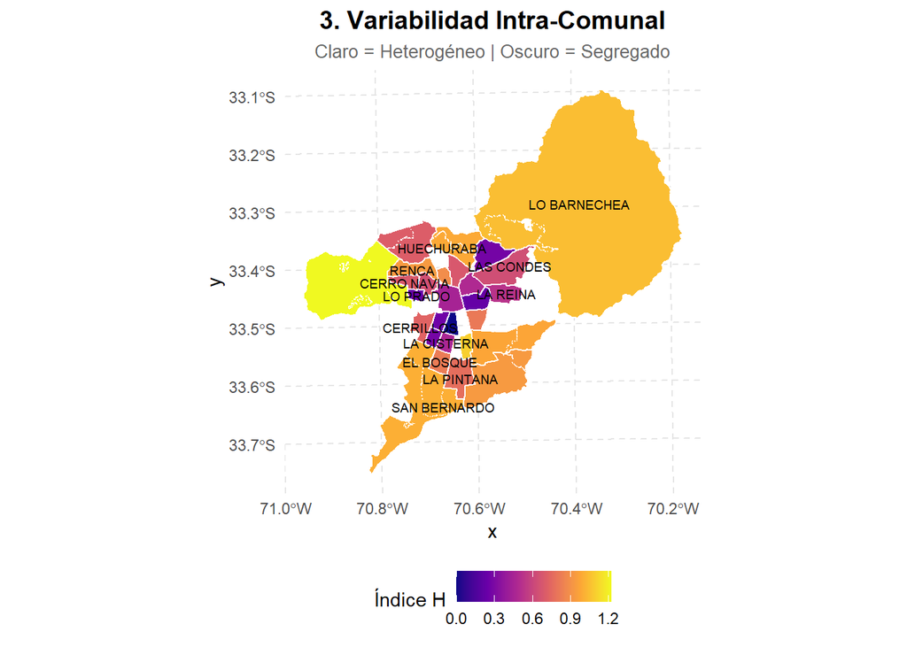

```r
df_shannon = sf_master %>% st_drop_geometry() %>%
  group_by(nom_comuna, cluster) %>% summarise(n=n(), .groups='drop') %>%
  group_by(nom_comuna) %>% mutate(prop=n/sum(n)) %>%
  summarise(indice_shannon = -sum(prop * log(prop))) %>% ungroup()

sf_shannon = sf_bordes %>% left_join(df_shannon, by="nom_comuna")

mapa_3 = ggplot() +
  geom_sf(data=sf_shannon, aes(fill=indice_shannon), color="white", lwd=0.5) +
  geom_sf_text(data=sf_shannon, aes(label=nom_comuna), size=2.5, color="black", check_overlap=TRUE) +
  scale_fill_viridis_c(option="plasma", name="Índice H") +
  labs(title="3. Variabilidad Intra-Comunal", subtitle="Claro = Heterogéneo | Oscuro = Segregado") + tema_pro
print(mapa_3)
```

```r
message("--- PROCESO FINALIZADO ---")
```

```
## --- PROCESO FINALIZADO ---
```